# Advanced Empirical Finance: Topics and Data Science

Portfolio sorts

Stefan Voigt

University of Copenhagen and Danish Finance Institute (DFI)

Spring 2027

## Today

# Sorting stocks on beta

## Where the CAPM stands

- **Lecture 6:** ten industries, 1960–2025. Higher betas came with barely higher average returns, but the GRS test could not reject the CAPM: the industries are too similar to each other and to the market
- **Today:** all US stocks in CRSP, sorted into 10 portfolios by their beta
- The betas are those of exercise 3: each month, a CAPM regression on the last 60 months (at least 48)

The CAPM says: the higher the beta, the higher the average return, one for one with the market premium

## Betas for every stock and month

- R
- Python

```r
betas <- crsp_monthly |>
  inner_join(factors_ff3_monthly, join_by(date)) |>
  estimate_betas("ret_excess ~ mkt_excess", months(window_length), min_obs = min_months)
```

```python
betas = tf.estimate_betas(
    crsp_monthly.join(factors_ff3_monthly, on="date"),
    "ret_excess ~ mkt_excess", lookback=f"{window_length}mo", min_obs=min_months,
)
```

- `estimate_betas()` from tidyfinance runs the regression on every 60-month window of every stock at once; exercise 3 uses it, too
- 2,401,783 betas for 18,498 stocks, 1963–2025; the median beta is 1.04

## What a portfolio sort does

- Each month, rank the stocks by **last month’s beta**, which investors know when they form the portfolios
- **Breakpoints** split them into 10 groups of equal size
- Each portfolio’s return is the **value-weighted** average return of its stocks
- **High minus low:** the top portfolio minus the bottom portfolio

In April 2020 the market rose by 13.6%: high-beta stocks rose most. Repeat every month and average

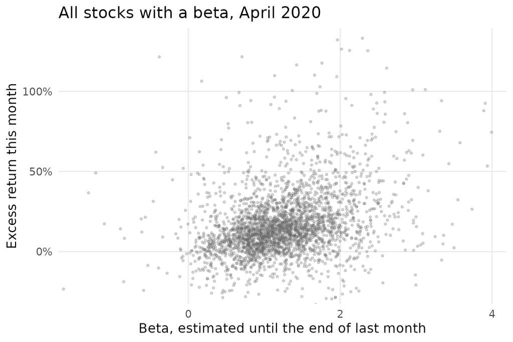

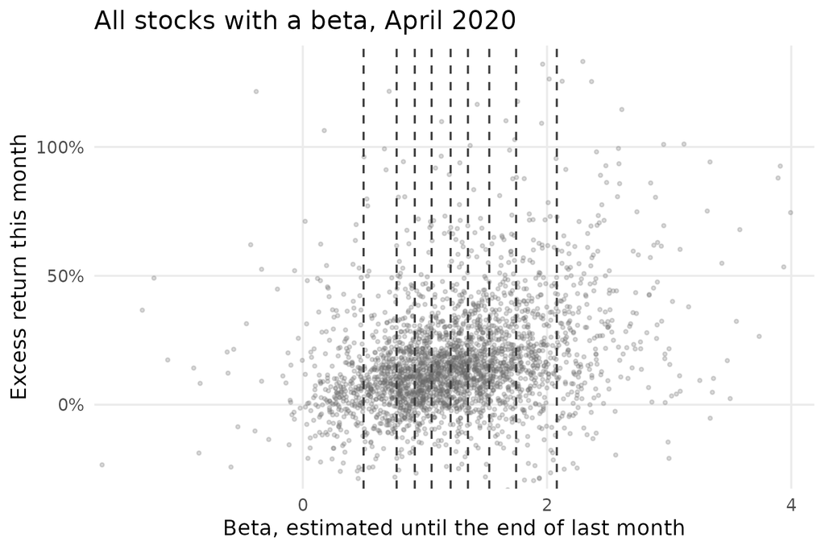

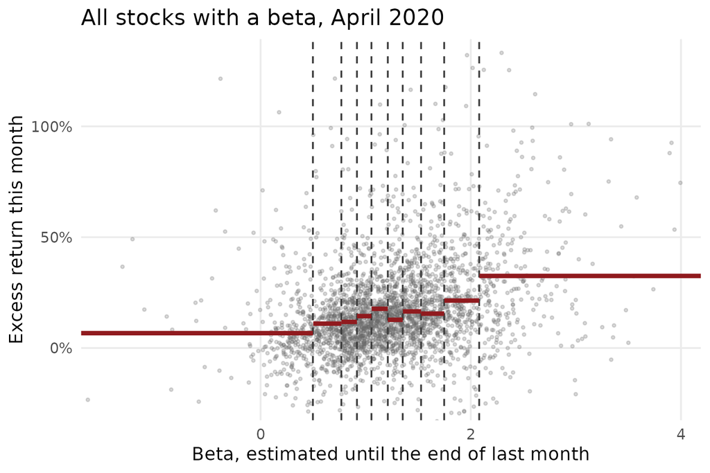

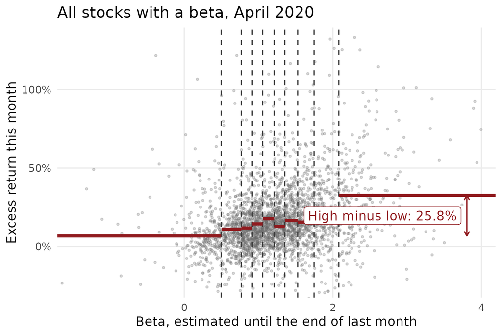